# Análisis evolución Covid-19 Chile casos y decesos (09/04/2020)

Claudio Bustos

09/4/2020

- Reportes anteriores: https://github.com/clbustos/analisis_covid19_chile

## Análisis de casos

La serie de casos se hace hace partir de los 5 casos, para facilitar la comparación desde un punto de un punto de partida común, ya que la aparición de los primeros casos siempre es un tanto errática. Como se señaló ayer, la serie de datos total tiene un patrón en 4 fases, las dos primeras de ascenso prácticamente exponencial (días 0 a 10, y 10 a 14), una también exponencial con menor tasa (14-20) y la actual, con un patrón de desaceleración constante que simila a una progresión lineal, que se mantiene hasta el día de hoy.

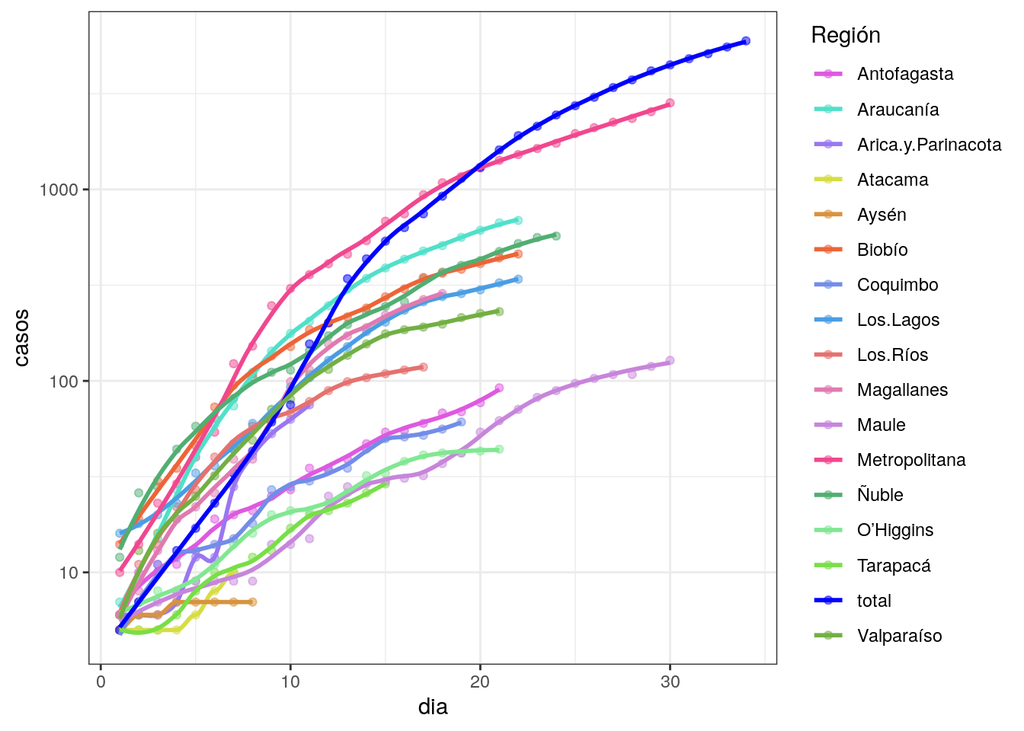

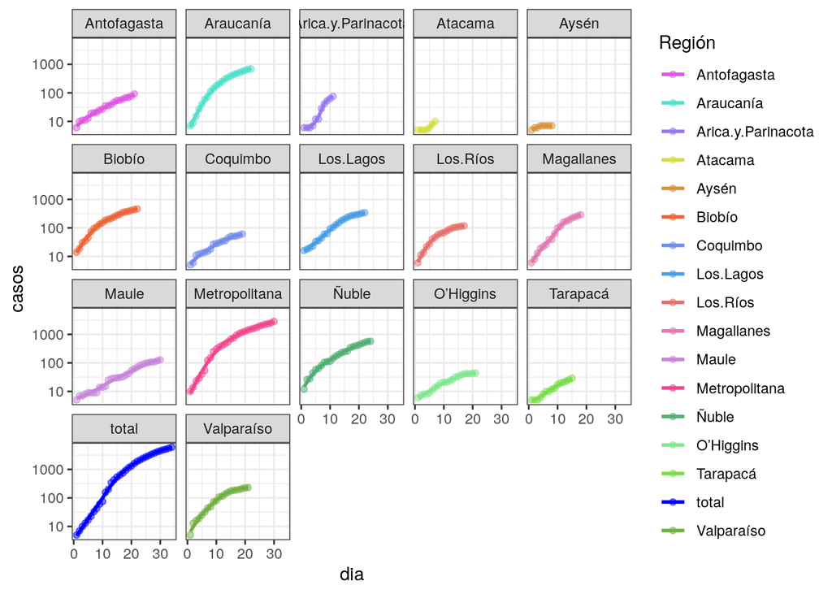

Si observamos la proporción de casos nuevos por región, observamos que Arica y Parinacota se encuentraba en una fase de expansión muy brusca, que ya se estaría controlando con un 20% el día de hoy. En todas las otras regiones se encuentra el patrón esperado de disminución diaria de casos por día al menos en los últimos 3 días, con diversos niveles de avance, excepto en Atacama, nuevamente.

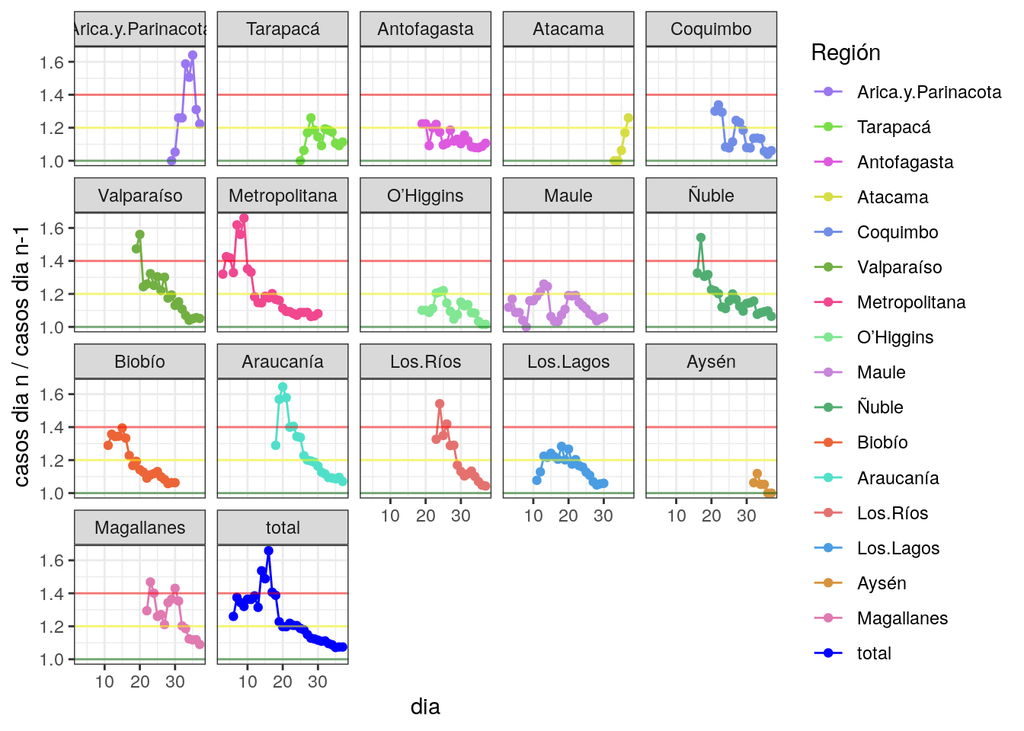

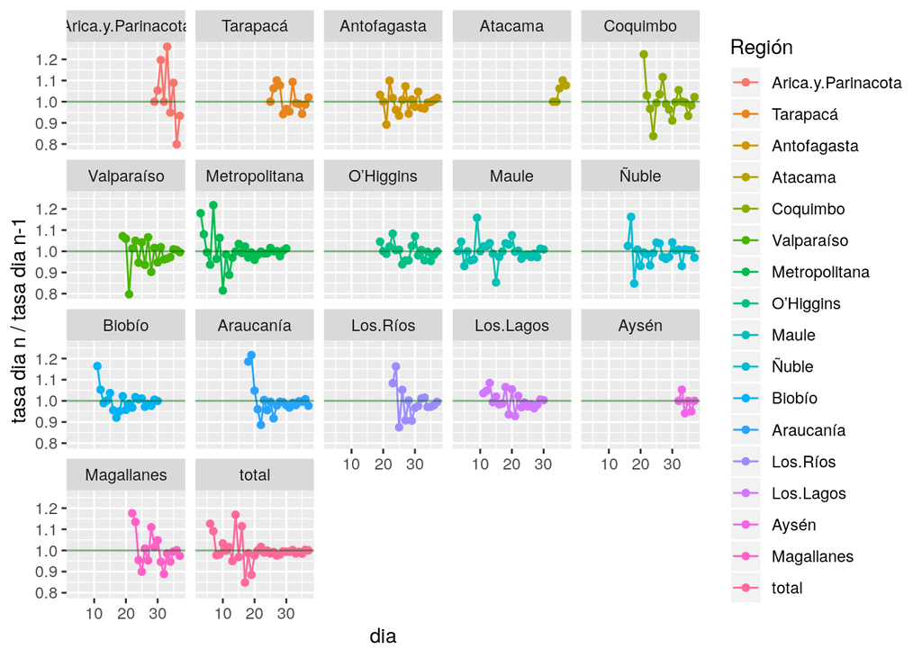

### Predicción para serie total

A partir del análisis del resultado del algoritmo de la última semana, para la predicción total se recorta la serie a partir de lo 50 casos.

Hemos eliminado la serie exponencial, ya que se aleja mucho del patrón observado. Agregamos hace un par de días una serie de tendencia + AR(4), ya que al observar los residuos del modelo T+AR(1) veamos autocorrelaciones a 3 y 4 días plazo.

Hoy se puede observar que las series T+AR(1) y T+AR(4) convergen en la predicción para 7 días más.

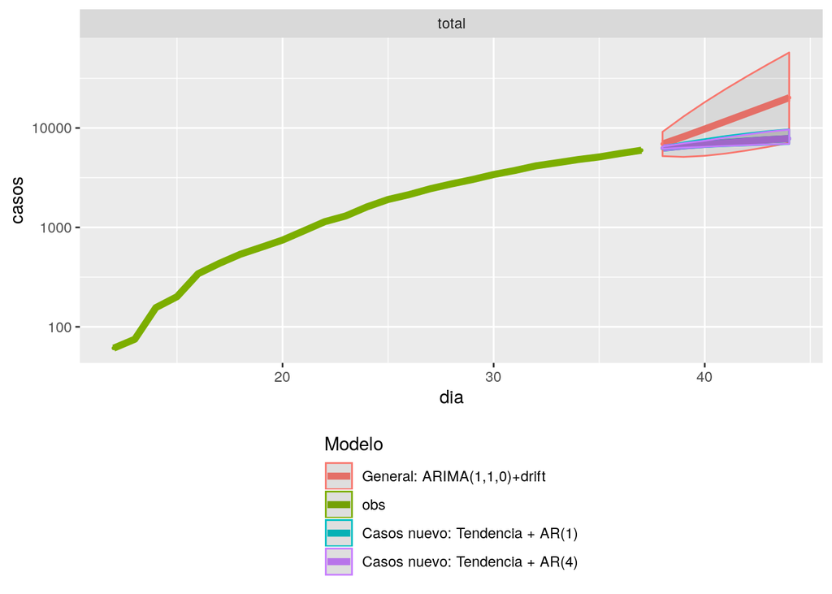

Casos nuevos: tendencia + AR(4) : total

|  | dia | casos | li | ls |
| --- | --- | --- | --- | --- |
| **27** | 38 | 6298 | 6174 | 6499 |
| **28** | 39 | 6592 | 6340 | 7020 |
| **29** | 40 | 6824 | 6467 | 7443 |
| **30** | 41 | 7104 | 6600 | 8031 |
| **31** | 42 | 7360 | 6718 | 8588 |
| **32** | 43 | 7628 | 6841 | 9172 |
| **33** | 44 | 7829 | 6930 | 9629 |

Casos nuevos: tendencia + AR(1) : total

|  | dia | casos | li | ls |
| --- | --- | --- | --- | --- |
| **27** | 38 | 6260 | 6134 | 6483 |
| **28** | 39 | 6599 | 6307 | 7151 |
| **29** | 40 | 6876 | 6442 | 7717 |
| **30** | 41 | 7156 | 6577 | 8298 |
| **31** | 42 | 7398 | 6693 | 8805 |
| **32** | 43 | 7626 | 6802 | 9282 |
| **33** | 44 | 7826 | 6897 | 9701 |

ARIMA(1,1,0) con deriva : total

|  | dia | casos | li | ls |
| --- | --- | --- | --- | --- |
| **27** | 38 | 6907 | 5215 | 9149 |
| **28** | 39 | 8184 | 5120 | 13081 |
| **29** | 40 | 9774 | 5252 | 18190 |
| **30** | 41 | 11706 | 5537 | 24746 |
| **31** | 42 | 14031 | 5943 | 33127 |
| **32** | 43 | 16824 | 6459 | 43825 |
| **33** | 44 | 20175 | 7084 | 57463 |

### Predicciones para serie total usando predicción por regiones.

Otro modelo posible de análisis es usar la suma de las predicciones parciales por región. No he calculado los intervalos de confianza, porque para que sean adecuados debería considerar la covarianza entre las series de las distintas regiones.

El modelo de sumas de T+AR(1) en 7 días predice 8092 vs un poco más de 7820 casos de los otros dos modelos.

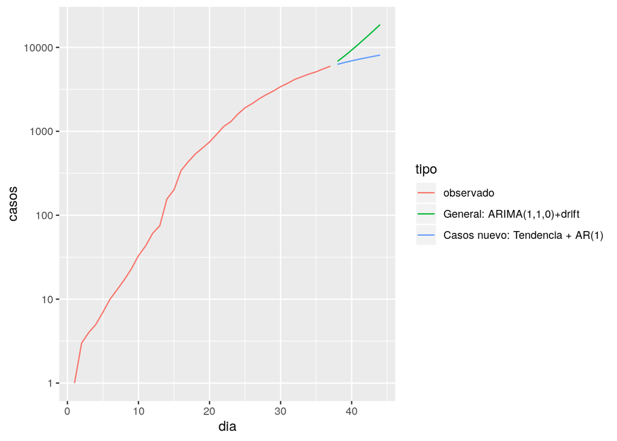

| dia | tipo | casos |
| --- | --- | --- |
| 1 | observado | 1 |
| 2 | observado | 3 |
| 3 | observado | 4 |
| 4 | observado | 5 |
| 5 | observado | 7 |
| 6 | observado | 10 |
| 7 | observado | 13 |
| 8 | observado | 17 |
| 9 | observado | 23 |
| 10 | observado | 33 |
| 11 | observado | 43 |
| 12 | observado | 61 |
| 13 | observado | 75 |
| 14 | observado | 156 |
| 15 | observado | 201 |
| 16 | observado | 342 |
| 17 | observado | 434 |
| 18 | observado | 537 |
| 19 | observado | 632 |
| 20 | observado | 746 |
| 21 | observado | 922 |
| 22 | observado | 1142 |
| 23 | observado | 1306 |
| 24 | observado | 1610 |
| 25 | observado | 1909 |
| 26 | observado | 2139 |
| 27 | observado | 2449 |
| 28 | observado | 2738 |
| 29 | observado | 3031 |
| 30 | observado | 3404 |
| 31 | observado | 3737 |
| 32 | observado | 4161 |
| 33 | observado | 4471 |
| 34 | observado | 4815 |
| 35 | observado | 5116 |
| 36 | observado | 5546 |
| 37 | observado | 5972 |
| 38 | General: ARIMA(1,1,0)+drift | 6816 |
| 39 | General: ARIMA(1,1,0)+drift | 7914 |
| 40 | General: ARIMA(1,1,0)+drift | 9294 |
| 41 | General: ARIMA(1,1,0)+drift | 10992 |
| 42 | General: ARIMA(1,1,0)+drift | 13067 |
| 43 | General: ARIMA(1,1,0)+drift | 15594 |
| 44 | General: ARIMA(1,1,0)+drift | 18668 |
| 38 | Casos nuevo: Tendencia + AR(1) | 6286 |
| 39 | Casos nuevo: Tendencia + AR(1) | 6607 |
| 40 | Casos nuevo: Tendencia + AR(1) | 6915 |
| 41 | Casos nuevo: Tendencia + AR(1) | 7217 |
| 42 | Casos nuevo: Tendencia + AR(1) | 7513 |
| 43 | Casos nuevo: Tendencia + AR(1) | 7804 |
| 44 | Casos nuevo: Tendencia + AR(1) | 8092 |

### Predicción por regiones

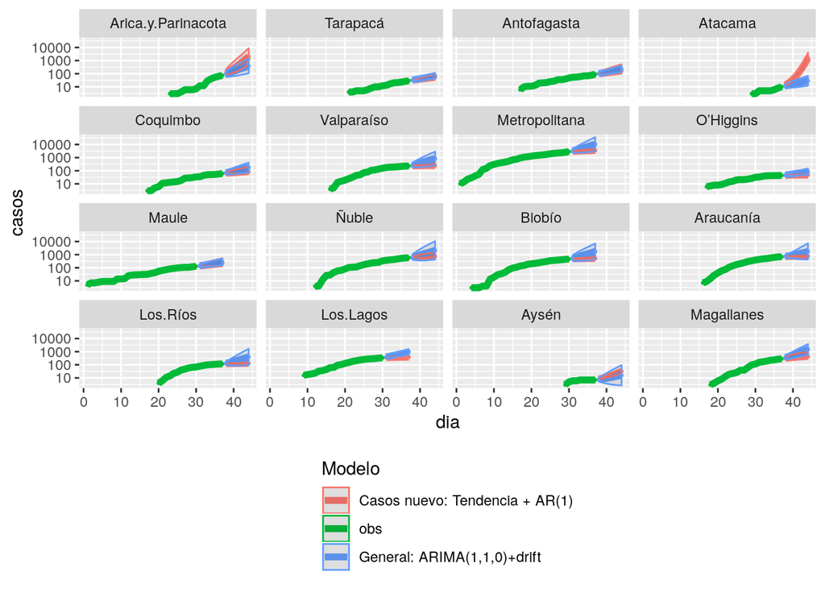

Las tablas por regiones se incluye en el Anexo I

## Decesos

Si observamos la serie de decesos, vemos que la serie nacional sigue un patrón exponencial. En el caso de la Araucanía se observa una disminución de las muertes en los últimos 4 días, en tanto que el proceso parece acelerarse en la Región Metropolitana.

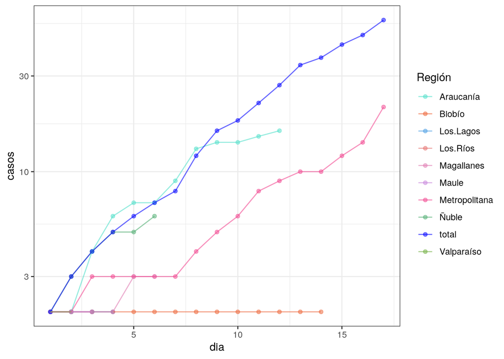

**Fuentes de información**: Principalmente, se utilizó el reporte diario del [MINSAL](https://www.minsal.cl/nuevo-coronavirus-2019-ncov/casos-confirmados-en-chile-covid-19/), usando [Wayback machine](https://archive.org/web/) para recopilar la información ya no disponible.

## Anexo I: Predicciones por región

Casos nuevos: tendencia + AR(1) : Arica.y.Parinacota

|  | dia | casos | li | ls |
| --- | --- | --- | --- | --- |
| **16** | 38 | 112.1 | 83.93 | 228.9 |
| **17** | 39 | 163.3 | 95.81 | 449.7 |
| **18** | 40 | 251.8 | 116.3 | 831.8 |
| **19** | 41 | 402.3 | 151.1 | 1482 |
| **20** | 42 | 668.9 | 212.8 | 2634 |
| **21** | 43 | 1154 | 325.2 | 4729 |
| **22** | 44 | 2064 | 535.9 | 8661 |

Casos nuevos: tendencia + AR(1) : Tarapacá

|  | dia | casos | li | ls |
| --- | --- | --- | --- | --- |
| **18** | 38 | 31.74 | 30.2 | 35.27 |
| **19** | 39 | 34.76 | 31.49 | 42.35 |
| **20** | 40 | 37.94 | 32.84 | 49.81 |
| **21** | 41 | 41.33 | 34.29 | 57.75 |
| **22** | 42 | 44.91 | 35.81 | 66.15 |
| **23** | 43 | 48.7 | 37.43 | 75.05 |
| **24** | 44 | 52.72 | 39.14 | 84.47 |

Casos nuevos: tendencia + AR(1) : Antofagasta

|  | dia | casos | li | ls |
| --- | --- | --- | --- | --- |
| **22** | 38 | 97.41 | 92.98 | 121.9 |
| **23** | 39 | 106 | 94.41 | 173.4 |
| **24** | 40 | 114.6 | 95.84 | 225.5 |
| **25** | 41 | 124.7 | 97.5 | 286.2 |
| **26** | 42 | 135.9 | 99.35 | 354 |
| **27** | 43 | 148.6 | 101.5 | 431.2 |
| **28** | 44 | 163.1 | 103.9 | 518.8 |

Casos nuevos: tendencia + AR(1) : Atacama

|  | dia | casos | li | ls |
| --- | --- | --- | --- | --- |
| **10** | 38 | 14.55 | 12.84 | 17.29 |
| **11** | 39 | 21.1 | 16.34 | 29.57 |
| **12** | 40 | 38.76 | 24.87 | 66.08 |
| **13** | 41 | 73.02 | 40.35 | 141.9 |
| **14** | 42 | 184.1 | 88.13 | 400.1 |
| **15** | 43 | 470.9 | 207.1 | 1091 |
| **16** | 44 | 1603 | 664.3 | 3893 |

Casos nuevos: tendencia + AR(1) : Coquimbo

|  | dia | casos | li | ls |
| --- | --- | --- | --- | --- |
| **22** | 38 | 64.01 | 61.57 | 76.9 |
| **23** | 39 | 67.34 | 62.19 | 94.72 |
| **24** | 40 | 70.73 | 62.83 | 112.9 |
| **25** | 41 | 74.22 | 63.48 | 131.5 |
| **26** | 42 | 77.79 | 64.14 | 150.7 |
| **27** | 43 | 81.45 | 64.83 | 170.2 |
| **28** | 44 | 85.18 | 65.52 | 190.2 |

Casos nuevos: tendencia + AR(1) : Valparaíso

|  | dia | casos | li | ls |
| --- | --- | --- | --- | --- |
| **23** | 38 | 235.8 | 232.1 | 246.2 |
| **24** | 39 | 239.7 | 233.3 | 258 |
| **25** | 40 | 242.8 | 234.4 | 267.8 |
| **26** | 41 | 245.1 | 235.1 | 274.9 |
| **27** | 42 | 246.8 | 235.6 | 280.1 |
| **28** | 43 | 247.9 | 236 | 283.8 |
| **29** | 44 | 248.7 | 236.3 | 286.2 |

Casos nuevos: tendencia + AR(1) : Metropolitana

|  | dia | casos | li | ls |
| --- | --- | --- | --- | --- |
| **31** | 31 | 2966 | 2885 | 3169 |
| **32** | 32 | 3084 | 2932 | 3466 |
| **33** | 33 | 3191 | 2974 | 3735 |
| **34** | 34 | 3286 | 3012 | 3975 |
| **35** | 35 | 3370 | 3046 | 4187 |
| **36** | 36 | 3444 | 3075 | 4373 |
| **37** | 37 | 3507 | 3100 | 4533 |

Casos nuevos: tendencia + AR(1) : O’Higgins

|  | dia | casos | li | ls |
| --- | --- | --- | --- | --- |
| **22** | 38 | 44.75 | 44.24 | 46.32 |
| **23** | 39 | 45.34 | 44.43 | 48.15 |
| **24** | 40 | 45.79 | 44.58 | 49.56 |
| **25** | 41 | 46.13 | 44.69 | 50.62 |
| **26** | 42 | 46.38 | 44.77 | 51.39 |
| **27** | 43 | 46.56 | 44.83 | 51.95 |
| **28** | 44 | 46.69 | 44.87 | 52.34 |

Casos nuevos: tendencia + AR(1) : Maule

|  | dia | casos | li | ls |
| --- | --- | --- | --- | --- |
| **31** | 31 | 137.1 | 129.9 | 171.8 |
| **32** | 32 | 146.8 | 131.8 | 220.3 |
| **33** | 33 | 157.2 | 133.9 | 272.6 |
| **34** | 34 | 168.4 | 136.1 | 329.1 |
| **35** | 35 | 180.6 | 138.6 | 390.1 |
| **36** | 36 | 193.7 | 141.2 | 455.9 |
| **37** | 37 | 207.8 | 144 | 527 |

Casos nuevos: tendencia + AR(1) : Ñuble

|  | dia | casos | li | ls |
| --- | --- | --- | --- | --- |
| **27** | 38 | 605.9 | 578.4 | 735.2 |
| **28** | 39 | 632.1 | 583.8 | 862.1 |
| **29** | 40 | 658.2 | 589.2 | 988.1 |
| **30** | 41 | 682.4 | 594.2 | 1106 |
| **31** | 42 | 705 | 598.9 | 1215 |
| **32** | 43 | 725.8 | 603.2 | 1315 |
| **33** | 44 | 744.7 | 607.1 | 1407 |

Casos nuevos: tendencia + AR(1) : Biobío

|  | dia | casos | li | ls |
| --- | --- | --- | --- | --- |
| **28** | 31 | 474.8 | 465.6 | 499.5 |
| **29** | 32 | 487.2 | 470.2 | 532.6 |
| **30** | 33 | 497.3 | 474 | 559.4 |
| **31** | 34 | 505.2 | 477 | 580.6 |
| **32** | 35 | 511.4 | 479.3 | 597.1 |
| **33** | 36 | 516.1 | 481 | 609.6 |
| **34** | 37 | 519.6 | 482.3 | 618.9 |

Casos nuevos: tendencia + AR(1) : Araucanía

|  | dia | casos | li | ls |
| --- | --- | --- | --- | --- |
| **23** | 38 | 711.6 | 700.8 | 732.5 |
| **24** | 39 | 729.6 | 710.1 | 767.1 |
| **25** | 40 | 743.5 | 717.4 | 793.8 |
| **26** | 41 | 753.9 | 722.8 | 813.8 |
| **27** | 42 | 761.4 | 726.7 | 828.2 |
| **28** | 43 | 766.8 | 729.5 | 838.5 |
| **29** | 44 | 770.4 | 731.4 | 845.5 |

Casos nuevos: tendencia + AR(1) : Los.Ríos

|  | dia | casos | li | ls |
| --- | --- | --- | --- | --- |
| **19** | 38 | 120.9 | 119.4 | 124.2 |
| **20** | 39 | 123.2 | 120.4 | 129.2 |
| **21** | 40 | 124.9 | 121.2 | 132.9 |
| **22** | 41 | 126.1 | 121.8 | 135.6 |
| **23** | 42 | 127 | 122.1 | 137.4 |
| **24** | 43 | 127.5 | 122.4 | 138.7 |
| **25** | 44 | 127.9 | 122.6 | 139.5 |

Casos nuevos: tendencia + AR(1) : Los.Lagos

|  | dia | casos | li | ls |
| --- | --- | --- | --- | --- |
| **23** | 31 | 350.8 | 344.1 | 368.1 |
| **24** | 32 | 360.1 | 347.4 | 395 |
| **25** | 33 | 367.3 | 349.8 | 416 |
| **26** | 34 | 372.9 | 351.7 | 432.4 |
| **27** | 35 | 377.1 | 353.2 | 444.6 |
| **28** | 36 | 380.1 | 354.2 | 453.6 |
| **29** | 37 | 382.3 | 354.9 | 460 |

Casos nuevos: tendencia + AR(1) : Aysén

|  | dia | casos | li | ls |
| --- | --- | --- | --- | --- |
| **10** | 38 | 8.33 | 7.94 | 8.87 |
| **11** | 39 | 9.83 | 8.96 | 11.09 |
| **12** | 40 | 11.82 | 10.29 | 14.06 |
| **13** | 41 | 14.42 | 12.03 | 17.96 |
| **14** | 42 | 18.12 | 14.49 | 23.51 |
| **15** | 43 | 23.52 | 18.09 | 31.63 |
| **16** | 44 | 31.9 | 23.67 | 44.2 |

Casos nuevos: tendencia + AR(1) : Magallanes

|  | dia | casos | li | ls |
| --- | --- | --- | --- | --- |
| **21** | 38 | 312.7 | 292.3 | 399.7 |
| **22** | 39 | 336.6 | 297.6 | 506.9 |
| **23** | 40 | 359.9 | 302.8 | 611.8 |
| **24** | 41 | 381.6 | 307.6 | 709.2 |
| **25** | 42 | 401.4 | 312 | 798.6 |
| **26** | 43 | 419.3 | 316 | 879.1 |
| **27** | 44 | 435.1 | 319.5 | 950 |

ARIMA(1,1,0) con deriva : Arica.y.Parinacota

|  | dia | casos | li | ls |
| --- | --- | --- | --- | --- |
| **16** | 38 | 94.9 | 57.1 | 157.7 |
| **17** | 39 | 119.6 | 59.77 | 239.2 |
| **18** | 40 | 150.7 | 65.04 | 349.1 |
| **19** | 41 | 189.9 | 72.36 | 498.3 |
| **20** | 42 | 239.3 | 81.67 | 701.2 |
| **21** | 43 | 301.6 | 93.13 | 976.6 |
| **22** | 44 | 380.1 | 107 | 1349 |

ARIMA(1,1,0) con deriva : Tarapacá

|  | dia | casos | li | ls |
| --- | --- | --- | --- | --- |
| **18** | 38 | 32.9 | 26.96 | 40.15 |
| **19** | 39 | 37.26 | 28.5 | 48.7 |
| **20** | 40 | 42.2 | 30.54 | 58.32 |
| **21** | 41 | 47.81 | 33 | 69.25 |
| **22** | 42 | 54.15 | 35.85 | 81.79 |
| **23** | 43 | 61.34 | 39.1 | 96.22 |
| **24** | 44 | 69.48 | 42.76 | 112.9 |

ARIMA(1,1,0) con deriva : Antofagasta

|  | dia | casos | li | ls |
| --- | --- | --- | --- | --- |
| **22** | 38 | 104.1 | 80.71 | 134.2 |
| **23** | 39 | 119.1 | 86.15 | 164.6 |
| **24** | 40 | 135.9 | 92.33 | 200.2 |
| **25** | 41 | 155.3 | 100 | 241.1 |
| **26** | 42 | 177.3 | 108.9 | 288.7 |
| **27** | 43 | 202.5 | 119.1 | 344.3 |
| **28** | 44 | 231.3 | 130.7 | 409.3 |

ARIMA(1,1,0) con deriva : Atacama

|  | dia | casos | li | ls |
| --- | --- | --- | --- | --- |
| **10** | 38 | 11.47 | 7.8 | 16.87 |
| **11** | 39 | 13.4 | 8.21 | 21.87 |
| **12** | 40 | 15.59 | 8.68 | 28 |
| **13** | 41 | 18.16 | 9.34 | 35.33 |
| **14** | 42 | 21.15 | 10.12 | 44.2 |
| **15** | 43 | 24.63 | 11.04 | 54.94 |
| **16** | 44 | 28.68 | 12.1 | 67.97 |

ARIMA(1,1,0) con deriva : Coquimbo

|  | dia | casos | li | ls |
| --- | --- | --- | --- | --- |
| **22** | 38 | 71.18 | 50.8 | 99.75 |
| **23** | 39 | 82.78 | 51.98 | 131.8 |
| **24** | 40 | 96.29 | 54.7 | 169.5 |
| **25** | 41 | 112 | 58.44 | 214.6 |
| **26** | 42 | 130.3 | 63.06 | 269.1 |
| **27** | 43 | 151.5 | 68.53 | 335 |
| **28** | 44 | 176.2 | 74.87 | 414.9 |

ARIMA(1,1,0) con deriva : Valparaíso

|  | dia | casos | li | ls |
| --- | --- | --- | --- | --- |
| **23** | 38 | 272.5 | 181.9 | 408.4 |
| **24** | 39 | 329.2 | 178.8 | 606.3 |
| **25** | 40 | 398.8 | 185.2 | 858.7 |
| **26** | 41 | 483.1 | 197 | 1185 |
| **27** | 42 | 585.4 | 213.1 | 1608 |
| **28** | 43 | 709.2 | 233.1 | 2158 |
| **29** | 44 | 859.3 | 257.3 | 2870 |

ARIMA(1,1,0) con deriva : Metropolitana

|  | dia | casos | li | ls |
| --- | --- | --- | --- | --- |
| **31** | 31 | 3328 | 2434 | 4552 |
| **32** | 32 | 3995 | 2342 | 6814 |
| **33** | 33 | 4835 | 2362 | 9899 |
| **34** | 34 | 5869 | 2456 | 14024 |
| **35** | 35 | 7133 | 2610 | 19493 |
| **36** | 36 | 8673 | 2816 | 26709 |
| **37** | 37 | 10548 | 3074 | 36198 |

ARIMA(1,1,0) con deriva : O’Higgins

|  | dia | casos | li | ls |
| --- | --- | --- | --- | --- |
| **22** | 38 | 47.49 | 40.77 | 55.32 |
| **23** | 39 | 52.08 | 40.55 | 66.89 |
| **24** | 40 | 57.39 | 41.35 | 79.67 |
| **25** | 41 | 63.34 | 42.76 | 93.81 |
| **26** | 42 | 69.93 | 44.64 | 109.5 |
| **27** | 43 | 77.21 | 46.88 | 127.2 |
| **28** | 44 | 85.26 | 49.47 | 147 |

ARIMA(1,1,0) con deriva : Maule

|  | dia | casos | li | ls |
| --- | --- | --- | --- | --- |
| **31** | 31 | 143.7 | 111.7 | 184.9 |
| **32** | 32 | 160.5 | 114.8 | 224.5 |
| **33** | 33 | 179.4 | 119.8 | 268.7 |
| **34** | 34 | 200.5 | 126.3 | 318.2 |
| **35** | 35 | 224 | 134 | 374.5 |
| **36** | 36 | 250.3 | 142.9 | 438.6 |
| **37** | 37 | 279.8 | 152.9 | 511.8 |

ARIMA(1,1,0) con deriva : Ñuble

|  | dia | casos | li | ls |
| --- | --- | --- | --- | --- |
| **27** | 38 | 664.6 | 409.2 | 1080 |
| **28** | 39 | 798.7 | 369 | 1729 |
| **29** | 40 | 967.2 | 357.4 | 2617 |
| **30** | 41 | 1173 | 360.3 | 3822 |
| **31** | 42 | 1424 | 372.4 | 5446 |
| **32** | 43 | 1729 | 391.6 | 7631 |
| **33** | 44 | 2098 | 417.1 | 10557 |

ARIMA(1,1,0) con deriva : Biobío

|  | dia | casos | li | ls |
| --- | --- | --- | --- | --- |
| **28** | 31 | 553.5 | 335.8 | 912.4 |
| **29** | 32 | 670.9 | 324.6 | 1387 |
| **30** | 33 | 813.6 | 331.6 | 1996 |
| **31** | 34 | 986.6 | 348.2 | 2795 |
| **32** | 35 | 1196 | 372.2 | 3846 |
| **33** | 36 | 1451 | 402.8 | 5226 |
| **34** | 37 | 1760 | 440 | 7036 |

ARIMA(1,1,0) con deriva : Araucanía

|  | dia | casos | li | ls |
| --- | --- | --- | --- | --- |
| **23** | 38 | 738.9 | 605.8 | 901.2 |
| **24** | 39 | 817.3 | 546.5 | 1222 |
| **25** | 40 | 925.6 | 500.1 | 1713 |
| **26** | 41 | 1067 | 466.3 | 2443 |
| **27** | 42 | 1247 | 443.1 | 3512 |
| **28** | 43 | 1474 | 428.8 | 5063 |
| **29** | 44 | 1754 | 422.1 | 7293 |

ARIMA(1,1,0) con deriva : Los.Ríos

|  | dia | casos | li | ls |
| --- | --- | --- | --- | --- |
| **19** | 38 | 131.9 | 98.74 | 176.1 |
| **20** | 39 | 153.6 | 90.28 | 261.4 |
| **21** | 40 | 183 | 86.35 | 387.8 |
| **22** | 41 | 220.7 | 85.61 | 568.9 |
| **23** | 42 | 267.9 | 87.24 | 822.6 |
| **24** | 43 | 326.4 | 90.79 | 1173 |
| **25** | 44 | 398.4 | 96.03 | 1652 |

ARIMA(1,1,0) con deriva : Los.Lagos

|  | dia | casos | li | ls |
| --- | --- | --- | --- | --- |
| **23** | 31 | 397.3 | 324.6 | 486.2 |
| **24** | 32 | 459.3 | 349.8 | 603.2 |
| **25** | 33 | 531.6 | 382.5 | 738.9 |
| **26** | 34 | 615.2 | 421.8 | 897.3 |
| **27** | 35 | 712 | 467.8 | 1084 |
| **28** | 36 | 824 | 520.8 | 1304 |
| **29** | 37 | 953.6 | 581.6 | 1564 |

ARIMA(1,1,0) con deriva : Aysén

|  | dia | casos | li | ls |
| --- | --- | --- | --- | --- |
| **10** | 38 | 7.45 | 5.25 | 10.56 |
| **11** | 39 | 8.21 | 4.29 | 15.69 |
| **12** | 40 | 9.22 | 3.66 | 23.22 |
| **13** | 41 | 10.48 | 3.25 | 33.81 |
| **14** | 42 | 11.99 | 2.98 | 48.33 |
| **15** | 43 | 13.77 | 2.79 | 67.86 |
| **16** | 44 | 15.83 | 2.67 | 93.8 |

ARIMA(1,1,0) con deriva : Magallanes

|  | dia | casos | li | ls |
| --- | --- | --- | --- | --- |
| **21** | 38 | 356.5 | 259.9 | 489 |
| **22** | 39 | 451.9 | 281.7 | 724.9 |
| **23** | 40 | 573.8 | 317.6 | 1036 |
| **24** | 41 | 728.7 | 365.4 | 1453 |
| **25** | 42 | 925.5 | 425.7 | 2012 |
| **26** | 43 | 1175 | 500.3 | 2762 |
| **27** | 44 | 1493 | 591.8 | 3767 |